# Risk Factor Analysis

## Outcome Variable

**Outcome Variable:** haz

## Predictor Variables

**Intervention Variable:** predfeed6

**Adjustment Set:**

- arm
- sex
- month
- brthmon
- W_mage
- meducyrs
- feducyrs
- hhwealth_quart
- hfoodsec
- W_mhtcm
- W_mwtkg
- W_mbmi
- vagbrth
- W_gagebrth
- W_birthwt
- W_birthlen
- W_nrooms
- W_nchldlt5
- W_parity
- impfloor
- impsan
- safeh20
- delta_W_mage
- delta_meducyrs
- delta_feducyrs
- delta_hhwealth_quart
- delta_hfoodsec
- delta_W_mhtcm
- delta_W_mwtkg
- delta_W_mbmi
- delta_vagbrth
- delta_W_gagebrth
- delta_W_birthwt
- delta_W_birthlen
- delta_W_nrooms
- delta_W_nchldlt5
- delta_W_parity
- delta_impfloor
- delta_impsan
- delta_safeh20

## Stratifying Variables

The analysis was stratified on these variable(s):

- agecat
- studyid
- country

## Data Summary

| agecat | studyid | country | predfeed6 | n_cell | n | outcome_variable |
| --- | --- | --- | --- | --- | --- | --- |
| Birth | EE | PAKISTAN | 1 | 38 | 42 | haz |
| Birth | EE | PAKISTAN | 0 | 4 | 42 | haz |
| Birth | GMS-Nepal | NEPAL | 1 | 419 | 563 | haz |
| Birth | GMS-Nepal | NEPAL | 0 | 144 | 563 | haz |
| Birth | JiVitA-3 | BANGLADESH | 1 | 10466 | 13423 | haz |
| Birth | JiVitA-3 | BANGLADESH | 0 | 2957 | 13423 | haz |
| Birth | JiVitA-4 | BANGLADESH | 1 | 2103 | 2632 | haz |
| Birth | JiVitA-4 | BANGLADESH | 0 | 529 | 2632 | haz |
| Birth | MAL-ED | BANGLADESH | 1 | 72 | 205 | haz |
| Birth | MAL-ED | BANGLADESH | 0 | 133 | 205 | haz |
| Birth | MAL-ED | BRAZIL | 1 | 6 | 60 | haz |
| Birth | MAL-ED | BRAZIL | 0 | 54 | 60 | haz |
| Birth | MAL-ED | INDIA | 1 | 4 | 39 | haz |
| Birth | MAL-ED | INDIA | 0 | 35 | 39 | haz |
| Birth | MAL-ED | NEPAL | 1 | 3 | 24 | haz |
| Birth | MAL-ED | NEPAL | 0 | 21 | 24 | haz |
| Birth | MAL-ED | PERU | 1 | 73 | 213 | haz |
| Birth | MAL-ED | PERU | 0 | 140 | 213 | haz |
| Birth | MAL-ED | SOUTH AFRICA | 1 | 1 | 91 | haz |
| Birth | MAL-ED | SOUTH AFRICA | 0 | 90 | 91 | haz |
| Birth | MAL-ED | TANZANIA, UNITED REPUBLIC OF | 1 | 0 | 113 | haz |
| Birth | MAL-ED | TANZANIA, UNITED REPUBLIC OF | 0 | 113 | 113 | haz |
| 6 months | EE | PAKISTAN | 1 | 43 | 48 | haz |
| 6 months | EE | PAKISTAN | 0 | 5 | 48 | haz |
| 6 months | GMS-Nepal | NEPAL | 1 | 406 | 547 | haz |
| 6 months | GMS-Nepal | NEPAL | 0 | 141 | 547 | haz |
| 6 months | JiVitA-3 | BANGLADESH | 1 | 7644 | 9901 | haz |
| 6 months | JiVitA-3 | BANGLADESH | 0 | 2257 | 9901 | haz |
| 6 months | JiVitA-4 | BANGLADESH | 1 | 3328 | 4272 | haz |
| 6 months | JiVitA-4 | BANGLADESH | 0 | 944 | 4272 | haz |
| 6 months | LCNI-5 | MALAWI | 1 | 47 | 272 | haz |
| 6 months | LCNI-5 | MALAWI | 0 | 225 | 272 | haz |
| 6 months | MAL-ED | BANGLADESH | 1 | 84 | 231 | haz |
| 6 months | MAL-ED | BANGLADESH | 0 | 147 | 231 | haz |
| 6 months | MAL-ED | BRAZIL | 1 | 30 | 209 | haz |
| 6 months | MAL-ED | BRAZIL | 0 | 179 | 209 | haz |
| 6 months | MAL-ED | INDIA | 1 | 11 | 218 | haz |
| 6 months | MAL-ED | INDIA | 0 | 207 | 218 | haz |
| 6 months | MAL-ED | NEPAL | 1 | 12 | 225 | haz |
| 6 months | MAL-ED | NEPAL | 0 | 213 | 225 | haz |
| 6 months | MAL-ED | PERU | 1 | 92 | 271 | haz |
| 6 months | MAL-ED | PERU | 0 | 179 | 271 | haz |
| 6 months | MAL-ED | SOUTH AFRICA | 1 | 3 | 233 | haz |
| 6 months | MAL-ED | SOUTH AFRICA | 0 | 230 | 233 | haz |
| 6 months | MAL-ED | TANZANIA, UNITED REPUBLIC OF | 1 | 1 | 232 | haz |
| 6 months | MAL-ED | TANZANIA, UNITED REPUBLIC OF | 0 | 231 | 232 | haz |
| 6 months | SAS-FoodSuppl | INDIA | 1 | 0 | 168 | haz |
| 6 months | SAS-FoodSuppl | INDIA | 0 | 168 | 168 | haz |
| 24 months | EE | PAKISTAN | 1 | 20 | 23 | haz |
| 24 months | EE | PAKISTAN | 0 | 3 | 23 | haz |
| 24 months | GMS-Nepal | NEPAL | 1 | 356 | 470 | haz |
| 24 months | GMS-Nepal | NEPAL | 0 | 114 | 470 | haz |
| 24 months | JiVitA-3 | BANGLADESH | 1 | 3926 | 5088 | haz |
| 24 months | JiVitA-3 | BANGLADESH | 0 | 1162 | 5088 | haz |
| 24 months | JiVitA-4 | BANGLADESH | 1 | 3292 | 4199 | haz |
| 24 months | JiVitA-4 | BANGLADESH | 0 | 907 | 4199 | haz |
| 24 months | LCNI-5 | MALAWI | 1 | 34 | 189 | haz |
| 24 months | LCNI-5 | MALAWI | 0 | 155 | 189 | haz |
| 24 months | MAL-ED | BANGLADESH | 1 | 76 | 205 | haz |
| 24 months | MAL-ED | BANGLADESH | 0 | 129 | 205 | haz |
| 24 months | MAL-ED | BRAZIL | 1 | 25 | 169 | haz |
| 24 months | MAL-ED | BRAZIL | 0 | 144 | 169 | haz |
| 24 months | MAL-ED | INDIA | 1 | 11 | 209 | haz |
| 24 months | MAL-ED | INDIA | 0 | 198 | 209 | haz |
| 24 months | MAL-ED | NEPAL | 1 | 12 | 219 | haz |
| 24 months | MAL-ED | NEPAL | 0 | 207 | 219 | haz |
| 24 months | MAL-ED | PERU | 1 | 68 | 201 | haz |
| 24 months | MAL-ED | PERU | 0 | 133 | 201 | haz |
| 24 months | MAL-ED | SOUTH AFRICA | 1 | 3 | 216 | haz |
| 24 months | MAL-ED | SOUTH AFRICA | 0 | 213 | 216 | haz |
| 24 months | MAL-ED | TANZANIA, UNITED REPUBLIC OF | 1 | 1 | 202 | haz |
| 24 months | MAL-ED | TANZANIA, UNITED REPUBLIC OF | 0 | 201 | 202 | haz |

The following strata were considered:

- agecat: 24 months, studyid: EE, country: PAKISTAN
- agecat: 24 months, studyid: GMS-Nepal, country: NEPAL
- agecat: 24 months, studyid: JiVitA-3, country: BANGLADESH
- agecat: 24 months, studyid: JiVitA-4, country: BANGLADESH
- agecat: 24 months, studyid: LCNI-5, country: MALAWI
- agecat: 24 months, studyid: MAL-ED, country: BANGLADESH
- agecat: 24 months, studyid: MAL-ED, country: BRAZIL
- agecat: 24 months, studyid: MAL-ED, country: INDIA
- agecat: 24 months, studyid: MAL-ED, country: NEPAL
- agecat: 24 months, studyid: MAL-ED, country: PERU
- agecat: 24 months, studyid: MAL-ED, country: SOUTH AFRICA
- agecat: 24 months, studyid: MAL-ED, country: TANZANIA, UNITED REPUBLIC OF
- agecat: 6 months, studyid: EE, country: PAKISTAN
- agecat: 6 months, studyid: GMS-Nepal, country: NEPAL
- agecat: 6 months, studyid: JiVitA-3, country: BANGLADESH
- agecat: 6 months, studyid: JiVitA-4, country: BANGLADESH
- agecat: 6 months, studyid: LCNI-5, country: MALAWI
- agecat: 6 months, studyid: MAL-ED, country: BANGLADESH
- agecat: 6 months, studyid: MAL-ED, country: BRAZIL
- agecat: 6 months, studyid: MAL-ED, country: INDIA
- agecat: 6 months, studyid: MAL-ED, country: NEPAL
- agecat: 6 months, studyid: MAL-ED, country: PERU
- agecat: 6 months, studyid: MAL-ED, country: SOUTH AFRICA
- agecat: 6 months, studyid: MAL-ED, country: TANZANIA, UNITED REPUBLIC OF
- agecat: 6 months, studyid: SAS-FoodSuppl, country: INDIA
- agecat: Birth, studyid: EE, country: PAKISTAN
- agecat: Birth, studyid: GMS-Nepal, country: NEPAL
- agecat: Birth, studyid: JiVitA-3, country: BANGLADESH
- agecat: Birth, studyid: JiVitA-4, country: BANGLADESH
- agecat: Birth, studyid: MAL-ED, country: BANGLADESH
- agecat: Birth, studyid: MAL-ED, country: BRAZIL
- agecat: Birth, studyid: MAL-ED, country: INDIA
- agecat: Birth, studyid: MAL-ED, country: NEPAL
- agecat: Birth, studyid: MAL-ED, country: PERU
- agecat: Birth, studyid: MAL-ED, country: SOUTH AFRICA
- agecat: Birth, studyid: MAL-ED, country: TANZANIA, UNITED REPUBLIC OF

### Dropped Strata

Some strata were dropped due to rare outcomes:

- agecat: Birth, studyid: EE, country: PAKISTAN
- agecat: Birth, studyid: MAL-ED, country: INDIA
- agecat: Birth, studyid: MAL-ED, country: NEPAL
- agecat: Birth, studyid: MAL-ED, country: SOUTH AFRICA
- agecat: Birth, studyid: MAL-ED, country: TANZANIA, UNITED REPUBLIC OF
- agecat: 6 months, studyid: MAL-ED, country: SOUTH AFRICA
- agecat: 6 months, studyid: MAL-ED, country: TANZANIA, UNITED REPUBLIC OF
- agecat: 6 months, studyid: SAS-FoodSuppl, country: INDIA
- agecat: 24 months, studyid: EE, country: PAKISTAN
- agecat: 24 months, studyid: MAL-ED, country: SOUTH AFRICA
- agecat: 24 months, studyid: MAL-ED, country: TANZANIA, UNITED REPUBLIC OF

## Methods Detail

We’re interested in the causal parameters $E[Y_a]$ for all values of $a \in \mathcal{A}$. These parameters represent the mean outcome if, possibly contrary to fact, we intervened to set all units to have $A=a$. Under the randomization and positivity assumptions, these are identified by the statistical parameters $\psi_a=E_W[E_{Y|A,W}(Y|A=a,W)]$. In addition, we’re interested in the mean of $Y$, $E[Y]$ under no intervention (the observed mean). We will estimate these parameters by using SuperLearner to fit the relevant likelihood factors – $E_{Y|A,W}(Y|A=a,W)$ and $p(A=a|W)$, and then updating our likelihood fit using a joint TMLE.

For unadjusted analyses ($W=\{\}$), initial likelihoods were estimated using Lrnr_glm to estimate the simple $E(Y|A)$ and Lrnr_mean to estimate $p(A)$. For adjusted analyses, a small library containing Lrnr_glmnet, Lrnr_xgboost, and Lrnr_mean was used.

Having estimated these parameters, we will then use the delta method to estimate relative risks and attributable risks relative to a prespecified baseline level of $A$.

# Results Detail

## Results Plots

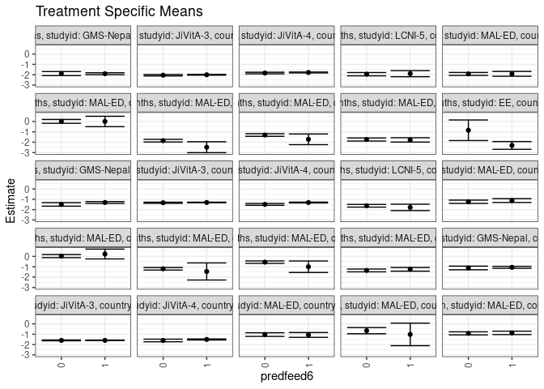

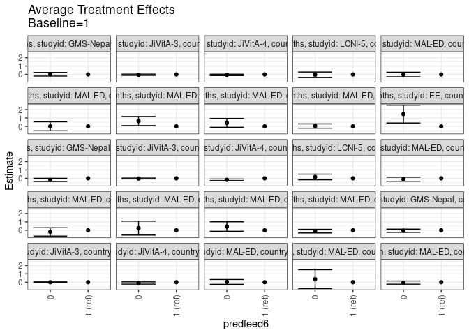

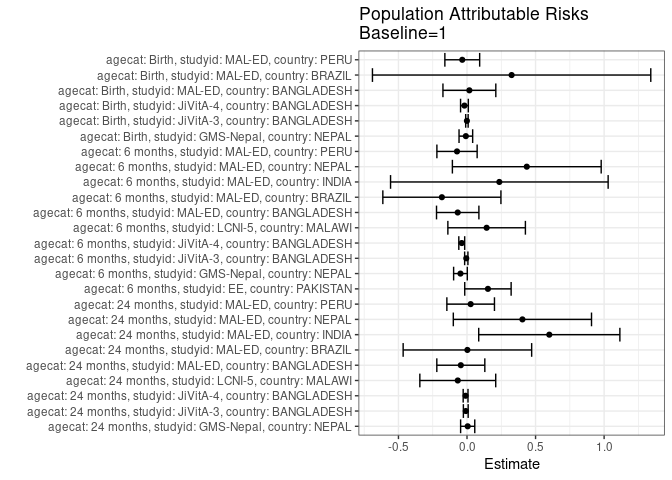

## Results Table

### Parameter: TSM

| agecat | studyid | country | intervention_level | baseline_level | estimate | ci_lower | ci_upper |
| --- | --- | --- | --- | --- | --- | --- | --- |
| Birth | GMS-Nepal | NEPAL | 1 | NA | -1.0556497 | -1.1530543 | -0.9582451 |
| Birth | GMS-Nepal | NEPAL | 0 | NA | -1.1145623 | -1.2908155 | -0.9383091 |
| Birth | JiVitA-3 | BANGLADESH | 1 | NA | -1.5948650 | -1.6196484 | -1.5700815 |
| Birth | JiVitA-3 | BANGLADESH | 0 | NA | -1.5979968 | -1.6373069 | -1.5586867 |
| Birth | JiVitA-4 | BANGLADESH | 1 | NA | -1.5086217 | -1.5604577 | -1.4567857 |
| Birth | JiVitA-4 | BANGLADESH | 0 | NA | -1.6057263 | -1.7311363 | -1.4803163 |
| Birth | MAL-ED | BANGLADESH | 1 | NA | -1.0702924 | -1.2999568 | -0.8406280 |
| Birth | MAL-ED | BANGLADESH | 0 | NA | -1.0362437 | -1.2111706 | -0.8613168 |
| Birth | MAL-ED | BRAZIL | 1 | NA | -1.0216667 | -2.1085384 | 0.0652051 |
| Birth | MAL-ED | BRAZIL | 0 | NA | -0.6601852 | -0.9595686 | -0.3608018 |
| Birth | MAL-ED | PERU | 1 | NA | -0.8719527 | -1.0364614 | -0.7074440 |
| Birth | MAL-ED | PERU | 0 | NA | -0.9185358 | -1.0662686 | -0.7708030 |
| 6 months | EE | PAKISTAN | 1 | NA | -2.3121318 | -2.6865239 | -1.9377397 |
| 6 months | EE | PAKISTAN | 0 | NA | -0.8473333 | -1.8424880 | 0.1478213 |
| 6 months | GMS-Nepal | NEPAL | 1 | NA | -1.3062426 | -1.3954554 | -1.2170299 |
| 6 months | GMS-Nepal | NEPAL | 0 | NA | -1.4950933 | -1.6643853 | -1.3258013 |
| 6 months | JiVitA-3 | BANGLADESH | 1 | NA | -1.3085156 | -1.3389576 | -1.2780735 |
| 6 months | JiVitA-3 | BANGLADESH | 0 | NA | -1.3328776 | -1.3822140 | -1.2835412 |
| 6 months | JiVitA-4 | BANGLADESH | 1 | NA | -1.3098191 | -1.3506119 | -1.2690264 |
| 6 months | JiVitA-4 | BANGLADESH | 0 | NA | -1.4902278 | -1.5800429 | -1.4004128 |
| 6 months | LCNI-5 | MALAWI | 1 | NA | -1.7827228 | -2.0911364 | -1.4743092 |
| 6 months | LCNI-5 | MALAWI | 0 | NA | -1.6253140 | -1.7563340 | -1.4942939 |
| 6 months | MAL-ED | BANGLADESH | 1 | NA | -1.1222511 | -1.3065240 | -0.9379781 |
| 6 months | MAL-ED | BANGLADESH | 0 | NA | -1.2358940 | -1.3915347 | -1.0802533 |
| 6 months | MAL-ED | BRAZIL | 1 | NA | 0.2308355 | -0.2437811 | 0.7054521 |
| 6 months | MAL-ED | BRAZIL | 0 | NA | 0.0308646 | -0.1194807 | 0.1812099 |
| 6 months | MAL-ED | INDIA | 1 | NA | -1.4546735 | -2.2793191 | -0.6300278 |
| 6 months | MAL-ED | INDIA | 0 | NA | -1.1994323 | -1.3216083 | -1.0772563 |
| 6 months | MAL-ED | NEPAL | 1 | NA | -0.9982367 | -1.5518851 | -0.4445884 |
| 6 months | MAL-ED | NEPAL | 0 | NA | -0.5547188 | -0.6730009 | -0.4364366 |
| 6 months | MAL-ED | PERU | 1 | NA | -1.2491505 | -1.4266795 | -1.0716214 |
| 6 months | MAL-ED | PERU | 0 | NA | -1.3560265 | -1.4912503 | -1.2208028 |
| 24 months | GMS-Nepal | NEPAL | 1 | NA | -1.9051666 | -2.0001636 | -1.8101696 |
| 24 months | GMS-Nepal | NEPAL | 0 | NA | -1.8875384 | -2.0835671 | -1.6915097 |
| 24 months | JiVitA-3 | BANGLADESH | 1 | NA | -2.0027889 | -2.0426878 | -1.9628899 |
| 24 months | JiVitA-3 | BANGLADESH | 0 | NA | -2.0436738 | -2.1128231 | -1.9745246 |
| 24 months | JiVitA-4 | BANGLADESH | 1 | NA | -1.7810991 | -1.8229763 | -1.7392219 |
| 24 months | JiVitA-4 | BANGLADESH | 0 | NA | -1.8348256 | -1.9110866 | -1.7585647 |
| 24 months | LCNI-5 | MALAWI | 1 | NA | -1.8978097 | -2.1906177 | -1.6050017 |
| 24 months | LCNI-5 | MALAWI | 0 | NA | -1.9449137 | -2.1037514 | -1.7860759 |
| 24 months | MAL-ED | BANGLADESH | 1 | NA | -1.9124866 | -2.1457468 | -1.6792264 |
| 24 months | MAL-ED | BANGLADESH | 0 | NA | -1.9212958 | -2.0633858 | -1.7792057 |
| 24 months | MAL-ED | BRAZIL | 1 | NA | 0.0032578 | -0.4986778 | 0.5051933 |
| 24 months | MAL-ED | BRAZIL | 0 | NA | 0.0108269 | -0.1745926 | 0.1962463 |
| 24 months | MAL-ED | INDIA | 1 | NA | -2.4865090 | -3.0136477 | -1.9593702 |
| 24 months | MAL-ED | INDIA | 0 | NA | -1.8523055 | -1.9842465 | -1.7203646 |
| 24 months | MAL-ED | NEPAL | 1 | NA | -1.7228535 | -2.2387368 | -1.2069701 |
| 24 months | MAL-ED | NEPAL | 0 | NA | -1.3069372 | -1.4324764 | -1.1813980 |
| 24 months | MAL-ED | PERU | 1 | NA | -1.7791057 | -1.9883412 | -1.5698702 |
| 24 months | MAL-ED | PERU | 0 | NA | -1.7401445 | -1.8892442 | -1.5910448 |

### Parameter: E(Y)

| agecat | studyid | country | intervention_level | baseline_level | estimate | ci_lower | ci_upper |
| --- | --- | --- | --- | --- | --- | --- | --- |
| Birth | GMS-Nepal | NEPAL | NA | NA | -1.0641208 | -1.1525364 | -0.9757052 |
| Birth | JiVitA-3 | BANGLADESH | NA | NA | -1.5955338 | -1.6186322 | -1.5724354 |
| Birth | JiVitA-4 | BANGLADESH | NA | NA | -1.5273138 | -1.5765339 | -1.4780937 |
| Birth | MAL-ED | BANGLADESH | NA | NA | -1.0530244 | -1.1913751 | -0.9146736 |
| Birth | MAL-ED | BRAZIL | NA | NA | -0.6963333 | -0.9881882 | -0.4044785 |
| Birth | MAL-ED | PERU | NA | NA | -0.9065728 | -1.0297267 | -0.7834188 |
| 6 months | EE | PAKISTAN | NA | NA | -2.1595486 | -2.5331781 | -1.7859192 |
| 6 months | GMS-Nepal | NEPAL | NA | NA | -1.3540280 | -1.4334801 | -1.2745760 |
| 6 months | JiVitA-3 | BANGLADESH | NA | NA | -1.3138259 | -1.3418712 | -1.2857806 |
| 6 months | JiVitA-4 | BANGLADESH | NA | NA | -1.3482303 | -1.3866421 | -1.3098185 |
| 6 months | LCNI-5 | MALAWI | NA | NA | -1.6395956 | -1.7592633 | -1.5199278 |
| 6 months | MAL-ED | BANGLADESH | NA | NA | -1.1900794 | -1.3096296 | -1.0705291 |
| 6 months | MAL-ED | BRAZIL | NA | NA | 0.0475758 | -0.0963508 | 0.1915023 |
| 6 months | MAL-ED | INDIA | NA | NA | -1.2188303 | -1.3423090 | -1.0953516 |
| 6 months | MAL-ED | NEPAL | NA | NA | -0.5622370 | -0.6774081 | -0.4470660 |
| 6 months | MAL-ED | PERU | NA | NA | -1.3220326 | -1.4308168 | -1.2132484 |
| 24 months | GMS-Nepal | NEPAL | NA | NA | -1.9002128 | -1.9869255 | -1.8135001 |
| 24 months | JiVitA-3 | BANGLADESH | NA | NA | -2.0118003 | -2.0479952 | -1.9756055 |
| 24 months | JiVitA-4 | BANGLADESH | NA | NA | -1.7914765 | -1.8297816 | -1.7531715 |
| 24 months | LCNI-5 | MALAWI | NA | NA | -1.9651323 | -2.1053230 | -1.8249415 |
| 24 months | MAL-ED | BANGLADESH | NA | NA | -1.9576341 | -2.0857597 | -1.8295086 |
| 24 months | MAL-ED | BRAZIL | NA | NA | 0.0061144 | -0.1625850 | 0.1748138 |
| 24 months | MAL-ED | INDIA | NA | NA | -1.8863397 | -2.0168508 | -1.7558287 |
| 24 months | MAL-ED | NEPAL | NA | NA | -1.3187671 | -1.4406685 | -1.1968657 |
| 24 months | MAL-ED | PERU | NA | NA | -1.7524710 | -1.8736426 | -1.6312994 |

### Parameter: ATE

| agecat | studyid | country | intervention_level | baseline_level | estimate | ci_lower | ci_upper |
| --- | --- | --- | --- | --- | --- | --- | --- |
| Birth | GMS-Nepal | NEPAL | 1 | 1 | 0.0000000 | 0.0000000 | 0.0000000 |
| Birth | GMS-Nepal | NEPAL | 0 | 1 | -0.0589126 | -0.2527805 | 0.1349552 |
| Birth | JiVitA-3 | BANGLADESH | 1 | 1 | 0.0000000 | 0.0000000 | 0.0000000 |
| Birth | JiVitA-3 | BANGLADESH | 0 | 1 | -0.0031319 | -0.0439294 | 0.0376657 |
| Birth | JiVitA-4 | BANGLADESH | 1 | 1 | 0.0000000 | 0.0000000 | 0.0000000 |
| Birth | JiVitA-4 | BANGLADESH | 0 | 1 | -0.0971046 | -0.2321623 | 0.0379531 |
| Birth | MAL-ED | BANGLADESH | 1 | 1 | 0.0000000 | 0.0000000 | 0.0000000 |
| Birth | MAL-ED | BANGLADESH | 0 | 1 | 0.0340487 | -0.2560299 | 0.3241273 |
| Birth | MAL-ED | BRAZIL | 1 | 1 | 0.0000000 | 0.0000000 | 0.0000000 |
| Birth | MAL-ED | BRAZIL | 0 | 1 | 0.3614815 | -0.7658697 | 1.4888326 |
| Birth | MAL-ED | PERU | 1 | 1 | 0.0000000 | 0.0000000 | 0.0000000 |
| Birth | MAL-ED | PERU | 0 | 1 | -0.0465831 | -0.2397181 | 0.1465518 |
| 6 months | EE | PAKISTAN | 1 | 1 | 0.0000000 | 0.0000000 | 0.0000000 |
| 6 months | EE | PAKISTAN | 0 | 1 | 1.4647984 | 0.4015477 | 2.5280492 |
| 6 months | GMS-Nepal | NEPAL | 1 | 1 | 0.0000000 | 0.0000000 | 0.0000000 |
| 6 months | GMS-Nepal | NEPAL | 0 | 1 | -0.1888507 | -0.3804249 | 0.0027235 |
| 6 months | JiVitA-3 | BANGLADESH | 1 | 1 | 0.0000000 | 0.0000000 | 0.0000000 |
| 6 months | JiVitA-3 | BANGLADESH | 0 | 1 | -0.0243620 | -0.0767745 | 0.0280505 |
| 6 months | JiVitA-4 | BANGLADESH | 1 | 1 | 0.0000000 | 0.0000000 | 0.0000000 |
| 6 months | JiVitA-4 | BANGLADESH | 0 | 1 | -0.1804087 | -0.2778834 | -0.0829340 |
| 6 months | LCNI-5 | MALAWI | 1 | 1 | 0.0000000 | 0.0000000 | 0.0000000 |
| 6 months | LCNI-5 | MALAWI | 0 | 1 | 0.1574089 | -0.1790792 | 0.4938969 |
| 6 months | MAL-ED | BANGLADESH | 1 | 1 | 0.0000000 | 0.0000000 | 0.0000000 |
| 6 months | MAL-ED | BANGLADESH | 0 | 1 | -0.1136430 | -0.3554909 | 0.1282050 |
| 6 months | MAL-ED | BRAZIL | 1 | 1 | 0.0000000 | 0.0000000 | 0.0000000 |
| 6 months | MAL-ED | BRAZIL | 0 | 1 | -0.1999709 | -0.6982258 | 0.2982839 |
| 6 months | MAL-ED | INDIA | 1 | 1 | 0.0000000 | 0.0000000 | 0.0000000 |
| 6 months | MAL-ED | INDIA | 0 | 1 | 0.2552411 | -0.5779358 | 1.0884181 |
| 6 months | MAL-ED | NEPAL | 1 | 1 | 0.0000000 | 0.0000000 | 0.0000000 |
| 6 months | MAL-ED | NEPAL | 0 | 1 | 0.4435180 | -0.1247128 | 1.0117488 |
| 6 months | MAL-ED | PERU | 1 | 1 | 0.0000000 | 0.0000000 | 0.0000000 |
| 6 months | MAL-ED | PERU | 0 | 1 | -0.1068761 | -0.3275467 | 0.1137946 |
| 24 months | GMS-Nepal | NEPAL | 1 | 1 | 0.0000000 | 0.0000000 | 0.0000000 |
| 24 months | GMS-Nepal | NEPAL | 0 | 1 | 0.0176282 | -0.1985813 | 0.2338377 |
| 24 months | JiVitA-3 | BANGLADESH | 1 | 1 | 0.0000000 | 0.0000000 | 0.0000000 |
| 24 months | JiVitA-3 | BANGLADESH | 0 | 1 | -0.0408850 | -0.1168337 | 0.0350637 |
| 24 months | JiVitA-4 | BANGLADESH | 1 | 1 | 0.0000000 | 0.0000000 | 0.0000000 |
| 24 months | JiVitA-4 | BANGLADESH | 0 | 1 | -0.0537265 | -0.1357817 | 0.0283287 |
| 24 months | LCNI-5 | MALAWI | 1 | 1 | 0.0000000 | 0.0000000 | 0.0000000 |
| 24 months | LCNI-5 | MALAWI | 0 | 1 | -0.0471040 | -0.3824869 | 0.2882789 |
| 24 months | MAL-ED | BANGLADESH | 1 | 1 | 0.0000000 | 0.0000000 | 0.0000000 |
| 24 months | MAL-ED | BANGLADESH | 0 | 1 | -0.0088092 | -0.2804704 | 0.2628520 |
| 24 months | MAL-ED | BRAZIL | 1 | 1 | 0.0000000 | 0.0000000 | 0.0000000 |
| 24 months | MAL-ED | BRAZIL | 0 | 1 | 0.0075691 | -0.5285784 | 0.5437165 |
| 24 months | MAL-ED | INDIA | 1 | 1 | 0.0000000 | 0.0000000 | 0.0000000 |
| 24 months | MAL-ED | INDIA | 0 | 1 | 0.6342034 | 0.0906241 | 1.1777828 |
| 24 months | MAL-ED | NEPAL | 1 | 1 | 0.0000000 | 0.0000000 | 0.0000000 |
| 24 months | MAL-ED | NEPAL | 0 | 1 | 0.4159163 | -0.1151825 | 0.9470150 |
| 24 months | MAL-ED | PERU | 1 | 1 | 0.0000000 | 0.0000000 | 0.0000000 |
| 24 months | MAL-ED | PERU | 0 | 1 | 0.0389611 | -0.2177274 | 0.2956497 |

### Parameter: PAR

| agecat | studyid | country | intervention_level | baseline_level | estimate | ci_lower | ci_upper |
| --- | --- | --- | --- | --- | --- | --- | --- |
| Birth | GMS-Nepal | NEPAL | 1 | NA | -0.0084711 | -0.0581289 | 0.0411868 |
| Birth | JiVitA-3 | BANGLADESH | 1 | NA | -0.0006688 | -0.0096511 | 0.0083134 |
| Birth | JiVitA-4 | BANGLADESH | 1 | NA | -0.0186922 | -0.0469644 | 0.0095801 |
| Birth | MAL-ED | BANGLADESH | 1 | NA | 0.0172680 | -0.1755183 | 0.2100544 |
| Birth | MAL-ED | BRAZIL | 1 | NA | 0.3253333 | -0.6896600 | 1.3403266 |
| Birth | MAL-ED | PERU | 1 | NA | -0.0346201 | -0.1615083 | 0.0922681 |
| 6 months | EE | PAKISTAN | 1 | NA | 0.1525832 | -0.0166253 | 0.3217917 |
| 6 months | GMS-Nepal | NEPAL | 1 | NA | -0.0477854 | -0.0976705 | 0.0020997 |
| 6 months | JiVitA-3 | BANGLADESH | 1 | NA | -0.0053103 | -0.0172643 | 0.0066437 |
| 6 months | JiVitA-4 | BANGLADESH | 1 | NA | -0.0384112 | -0.0598188 | -0.0170036 |
| 6 months | LCNI-5 | MALAWI | 1 | NA | 0.1431272 | -0.1396112 | 0.4258657 |
| 6 months | MAL-ED | BANGLADESH | 1 | NA | -0.0678283 | -0.2223791 | 0.0867225 |
| 6 months | MAL-ED | BRAZIL | 1 | NA | -0.1832598 | -0.6139213 | 0.2474018 |
| 6 months | MAL-ED | INDIA | 1 | NA | 0.2358432 | -0.5576609 | 1.0293472 |
| 6 months | MAL-ED | NEPAL | 1 | NA | 0.4359997 | -0.1066360 | 0.9786354 |
| 6 months | MAL-ED | PERU | 1 | NA | -0.0728821 | -0.2196764 | 0.0739122 |
| 24 months | GMS-Nepal | NEPAL | 1 | NA | 0.0049538 | -0.0466274 | 0.0565351 |
| 24 months | JiVitA-3 | BANGLADESH | 1 | NA | -0.0090115 | -0.0264719 | 0.0084490 |
| 24 months | JiVitA-4 | BANGLADESH | 1 | NA | -0.0103774 | -0.0279306 | 0.0071758 |
| 24 months | LCNI-5 | MALAWI | 1 | NA | -0.0673226 | -0.3440085 | 0.2093633 |
| 24 months | MAL-ED | BANGLADESH | 1 | NA | -0.0451476 | -0.2202056 | 0.1299105 |
| 24 months | MAL-ED | BRAZIL | 1 | NA | 0.0028566 | -0.4657742 | 0.4714874 |
| 24 months | MAL-ED | INDIA | 1 | NA | 0.6001692 | 0.0853859 | 1.1149526 |
| 24 months | MAL-ED | NEPAL | 1 | NA | 0.4040864 | -0.0998887 | 0.9080614 |
| 24 months | MAL-ED | PERU | 1 | NA | 0.0266347 | -0.1469431 | 0.2002125 |